# Clinical data specifics

Olga Potanina

2023-11-10

```r
knitr::opts_chunk$set(echo = TRUE, tidy = T, highlight = T, fig.align = "center")
library(tidyverse)
library(readxl)
library(openxlsx)
library(pROC)
library(gtsummary)
```

## Описательная статистика

```r
trauma <- read.xlsx ("trauma.xlsx")

trauma <- trauma %>%
  mutate(X1 = NULL,
         Hb = na_if(Hb, 0)) %>%
  separate ("Height", into = c("Height","x")) %>%
  mutate(Height = paste0(Height, ".", x),
         x = NULL,
         Height = as.numeric(Height),
         Sex = ifelse(Sex == "Female", "Женский", "Мужской"),
         Height = round ((Height * 2.54),2),
         Weight = round ((Weight / 2.2),2))
```

*Значения концентрации гемоглобина, равные нулю, были приняты за пропущенные значения.*

```r
trauma %>%
  select(-id, -Name) %>%
  tbl_summary(digits = list(all_continuous() ~ c(1, 1),
                                 all_categorical() ~ c(0, 1)),
              label = list("Sex" = "Пол",
                           "Age" = "Возраст, лет",
                           "Height" = "Рост, см",
                           "Weight" = "Вес, кг",
                           "SBP" = "Систолическое АД, мм.рт.ст.",
                           "DBP" = "Диастолическое АД, мм.рт.ст.",
                           "FOUR" = "Баллов по шкале комы FOUR",
                           "GSC" = "Баллов по шкале комы Глазго",
                           "Hb" = "Концентрация гемоглобина в крови, г/дл",
                           "Death" = "Смерть"
                           ))
```

| **Characteristic** | **N = 1,024**<sup>1</sup> |
| --- | --- |
| Пол |  |
| Женский | 384 (37.5%) |
| Мужской | 640 (62.5%) |
| Возраст, лет | 41.0 (29.0, 53.0) |
| Рост, см | 184.9 (177.0, 190.8) |
| Вес, кг | 88.1 (82.6, 93.4) |
| Систолическое АД, мм.рт.ст. | 110.0 (106.0, 116.0) |
| Диастолическое АД, мм.рт.ст. | 84.0 (78.0, 90.0) |
| Баллов по шкале комы FOUR | 9.0 (7.0, 11.0) |
| Баллов по шкале комы Глазго | 8.0 (6.0, 10.0) |
| Концентрация гемоглобина в крови, г/дл | 13.1 (12.1, 14.0) |
| Unknown | 16 |
| Смерть | 409 (39.9%) |

<sup>1</sup> n (%); Median (IQR)

### Количество и доля пациентов с анемией [^1]

```r
library(flextable)

trauma %>%
  filter(Hb > 0) %>%
  mutate (anemia = ifelse(Sex == "Женский" & Hb < 12, 1, ifelse(Sex == "Мужской" & Hb < 13.5, 1, 0))) %>%
    summarise("Количество пациентов с анемией, чел." = sum(anemia),
           "Доля пациентов с анемией, %" = sum(anemia)/n() * 100 ) %>% round(1) %>%
  flextable() %>% theme_apa() %>% width (j= c (1,2), width = 1.7)
```

| Количество пациентов с анемией, чел. | Доля пациентов с анемией, % |
| --- | --- |
| 458.00 | 45.40 |

## Индекс массы тела и ожирение

```r
trauma %>%
  mutate ("ИМТ" = round (Weight/(Height/100)^2,1),
          "Ожирение" = ifelse (ИМТ > 30, "Да", "Нет")) %>%
  select("ИМТ", "Ожирение") %>%
  tbl_summary (statistic = list(all_continuous() ~ "{mean} ({sd})"),
               digits = list(all_continuous() ~ c(1, 1),
                                 all_categorical() ~ c(0, 1)),
               label = list("ИМТ" = "ИМТ, кг/кв. м.",
                            "Ожирение" = "Ожирение (ИМТ > 30)"))
```

| **Characteristic** | **N = 1,024**<sup>1</sup> |
| --- | --- |
| ИМТ, кг/кв. м. | 26.1 (2.6) |
| Ожирение (ИМТ > 30) |  |
| Да | 70 (6.8%) |
| Нет | 954 (93.2%) |

<sup>1</sup> Mean (SD); n (%)

*Среднее значение ИМТ - 26,1 кг/кв.м, ожирение имелось у 6.8% пациентов*

## ROC-кривая для предсказания летального исхода в течение 24 часов по уровню гемоглобина при поступлении

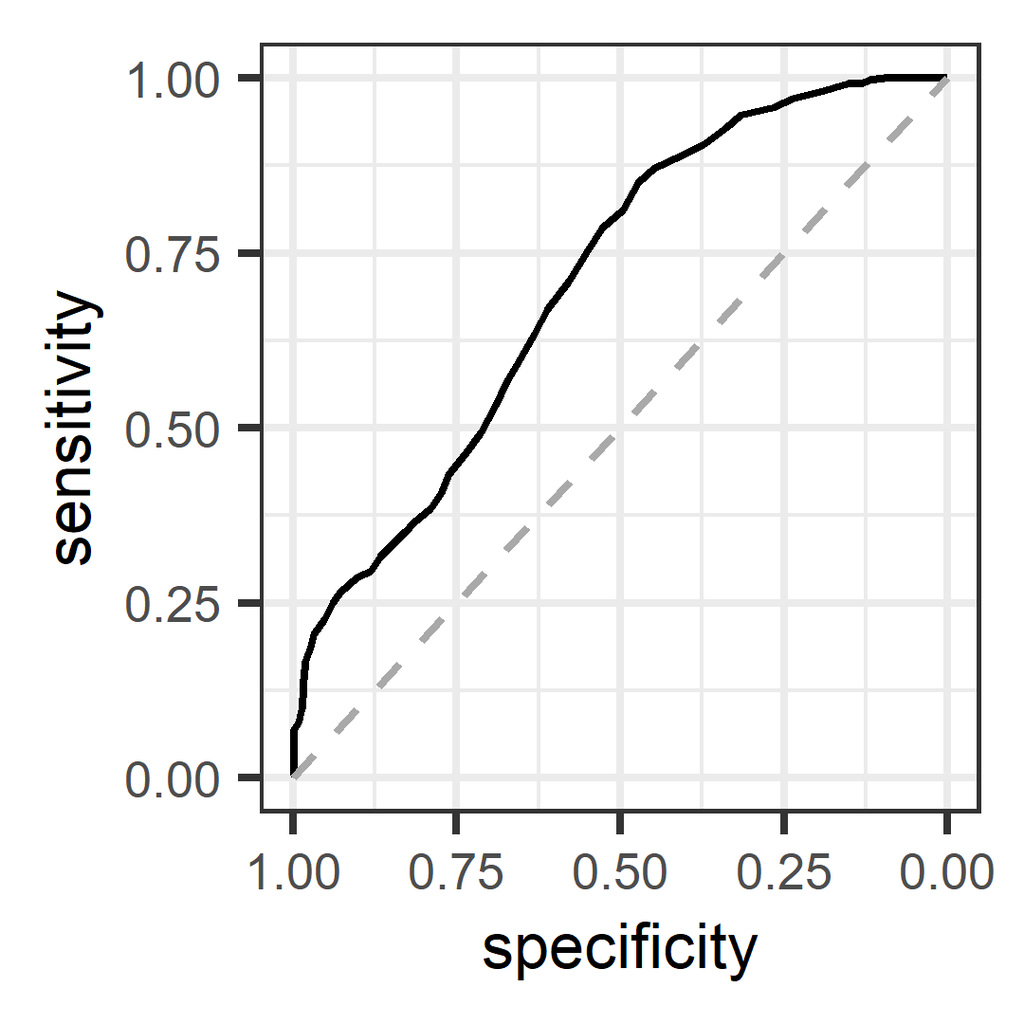

```r
  roc (Death ~ Hb, trauma, ci = TRUE) %>%
  ggroc() +
  geom_segment(aes(x = 1, xend = 0, y = 0, yend = 1), color="darkgrey", linetype="dashed") +
  theme_bw() +
  theme(text = element_text(size=8))
```

*Полученная форма кривой может быть обусловлена различием пациентов по полу, при том, что границы нормы для гемоглобна разные для разных полов, а также, возможным независимым влиянием пола на вероятность летального исхода*

### Площадь под ROC-кривой и 95% двусторонний ДИ для площади под ROC-кривой

```r
roc (Death ~ Hb, trauma, ci = TRUE, quiet = T)$auc
```

```
Area under the curve: 0.7078
```

```r
roc (Death ~ Hb, trauma, ci = TRUE, quiet = T)$ci
```

```
95% CI: 0.6763-0.7392 (DeLong)
```

*Полученные показатели говорят о возможности использования уровня гемоглобина при поступлении для предсказания летального исхода в течение 24 часов (площадь под ROC-кривой значимо отличается от 0.5)*

## ROC-анализ предсказания летального исхода в течение 24 часов по шкале комы Глазго

```r
roc (Death ~ GSC, trauma, ci = TRUE) %>%
  coords(x = "best", best.method = "closest.topleft") %>% round(2) %>%
   flextable() %>% theme_apa()
```

| threshold | specificity | sensitivity |
| --- | --- | --- |
| 7.50 | 0.81 | 0.86 |

```r
trauma %>%
  mutate ("ИМТ" = round (Weight/(Height/100)^2,1),
          Sex = ifelse(Sex == "Мужской", 1, 0)) %>%
  select(-c(id,Name)) %>%
  pivot_longer(cols = !Death) %>%
  rename("Переменная" = name) %>%
  group_by(Переменная) %>%
  summarise(AUC = roc(Death, value, ci = T)$ci[2] %>% round(3),
            "Нижняя граница 95% ДИ" = roc(Death, value, ci = T)$ci[1] %>% round(3),
            "Верхняя граница 95% ДИ" = roc(Death, value, ci = T)$ci[3] %>% round(3)) %>%
  flextable() %>% theme_apa() %>% width (j= c (3,4), width = 1.5)
```

| Переменная | AUC | Нижняя граница 95% ДИ | Верхняя граница 95% ДИ |
| --- | --- | --- | --- |
| Age | 0.53 | 0.49 | 0.56 |
| DBP | 0.74 | 0.71 | 0.77 |
| FOUR | 0.93 | 0.92 | 0.95 |
| GSC | 0.91 | 0.90 | 0.93 |
| Hb | 0.71 | 0.68 | 0.74 |
| Height | 0.48 | 0.44 | 0.52 |
| SBP | 0.79 | 0.76 | 0.81 |
| Sex | 0.49 | 0.46 | 0.52 |
| Weight | 0.52 | 0.48 | 0.55 |
| ИМТ | 0.50 | 0.46 | 0.54 |

*Наибольшей площадью под ROC-кривой обладает переменная, содержащая количество баллов по шкале комы FOUR при поступлении, следовательно данная переменная является оптимальной для определения вероятности смерти.*

*Наименьшая площадь под ROC-кривой у переменной Height (Рост)*

[^1]: анемией считалось снижение концентрации гемоглобина менее 13.5 г/дл - для мужчин, и менее 12.0 г/дл - для женщин.